# US Airlines Traffic - Data Analysis Report

## Combine columns and change DAY_OF_WEEK to char type

```r
merged_data1 <- merged_data1 %>%
  mutate(DATE = as.Date(paste(YEAR, MONTH, DAY, sep = "-")))%>% # combine year, month and day into new column
  mutate(DAYOFTHEWEEK = as.factor(case_when(
    DAY_OF_WEEK == 1 ~ "Monday",
    DAY_OF_WEEK == 2 ~ "Tuesday",
    DAY_OF_WEEK == 3 ~ "Wednesday",
    DAY_OF_WEEK == 4 ~ "Thursday",
    DAY_OF_WEEK == 5 ~ "Friday",
    DAY_OF_WEEK == 6 ~ "Saturday",
    DAY_OF_WEEK == 7 ~ "Sunday"
  )))%>%
  relocate(DATE: DAYOFTHEWEEK,AIRLINE, .before = IATA_CODE) # re-locate columns


# drop columns Months,Day and Day_of_week as we have combined these into Date column
#Finial dataset now contains only 28 columns and 228,252 rows
merged_data1 <- subset(merged_data1, select = -c(YEAR, MONTH, DAY,DAY_OF_WEEK))
```

```r
# NOTE that Date column is now of type 'date' and Dayoftheweek is now a 'factor'.
 sapply(merged_data1, class)
```

```
##      ORIGIN_AIRPORT             AIRPORT                CITY               STATE
##         "character"         "character"         "character"         "character"
##             COUNTRY            LATITUDE           LONGITUDE                DATE
##         "character"           "numeric"           "numeric"              "Date"
##        DAYOFTHEWEEK             AIRLINE           IATA_CODE       FLIGHT_NUMBER
##            "factor"         "character"         "character"           "integer"
##         TAIL_NUMBER DESTINATION_AIRPORT SCHEDULED_DEPARTURE      DEPARTURE_TIME
##         "character"         "character"           "integer"           "integer"
##     DEPARTURE_DELAY            TAXI_OUT          WHEELS_OFF      SCHEDULED_TIME
##           "integer"           "integer"           "integer"           "integer"
##        ELAPSED_TIME            AIR_TIME            DISTANCE           WHEELS_ON
##           "integer"           "integer"           "integer"           "integer"
##             TAXI_IN   SCHEDULED_ARRIVAL        ARRIVAL_TIME       ARRIVAL_DELAY
##           "integer"           "integer"           "integer"           "integer"
```

## Which is the Biggest Airline ?

**Southwest Airlines Co. is the biggest airlines with count of 49,892 outbound flights** ,

**Virgin America being the smallest** ,

```r
count_rows <- merged_data1 %>%
  group_by(AIRLINE) %>%
  summarize(count = n())%>%
arrange(desc(count))

count_rows
```

```
## # A tibble: 13 × 2
##    AIRLINE                      count
##    <chr>                        <int>
##  1 Southwest Airlines Co.       49892
##  2 American Airlines Inc.       36078
##  3 Delta Air Lines Inc.         35406
##  4 Skywest Airlines Inc.        22758
##  5 Atlantic Southeast Airlines  21576
##  6 United Air Lines Inc.        20199
##  7 American Eagle Airlines Inc. 10771
##  8 JetBlue Airways              10732
##  9 Alaska Airlines Inc.          7105
## 10 Spirit Air Lines              4591
## 11 Frontier Airlines Inc.        3629
## 12 Hawaiian Airlines Inc.        3129
## 13 Virgin America                2386
```

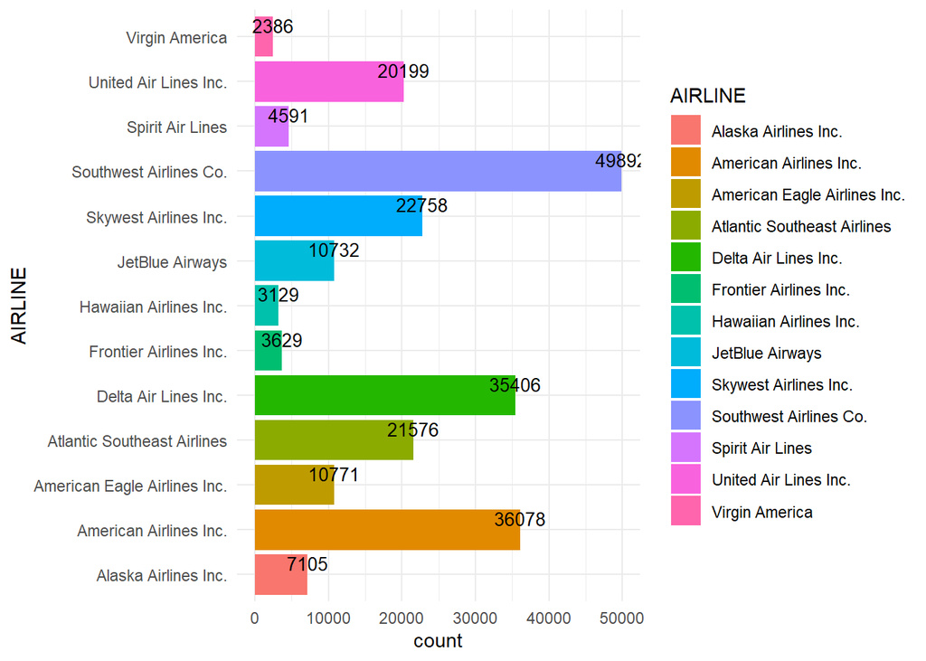

```r
ggplot(data=count_rows, aes(x=AIRLINE, y=count,fill=AIRLINE)) +
geom_bar(stat="identity")+
geom_text(aes(label=count), vjust=-0.3, size=3.5,color = "black")+
theme_minimal()+
 coord_flip()
```

## Which is the busiest Airport ?

**Hartsfield-Jackson Atlanta International Airport is the busiest airport with 14,869 outbound fights** ,

```r
count_ORIGIN_AIRPORT <- merged_data1 %>%
  group_by(AIRPORT,ORIGIN_AIRPORT) %>%
  summarize(count = n())%>%
arrange(desc(count))
count_ORIGIN_AIRPORT
```

```
## # A tibble: 309 × 3
## # Groups:   AIRPORT [309]
##    AIRPORT                                          ORIGIN_AIRPORT count
##    <chr>                                            <chr>          <int>
##  1 Hartsfield-Jackson Atlanta International Airport ATL            14869
##  2 Chicago O'Hare International Airport             ORD            12147
##  3 Dallas/Fort Worth International Airport          DFW            10202
##  4 Los Angeles International Airport                LAX             8454
##  5 Denver International Airport                     DEN             8378
##  6 Phoenix Sky Harbor International Airport         PHX             6275
##  7 San Francisco International Airport              SFO             6270
##  8 George Bush Intercontinental Airport             IAH             6172
##  9 McCarran International Airport                   LAS             5596
## 10 Seattle-Tacoma International Airport             SEA             5329
## # ℹ 299 more rows
```

## Top 5 airports were average departure delays are greater than 15 min

**Barnstable Municipal Airport** , **Kodiak Airport** , **Gustavus Airport** , **Martha’s Vineyard Airport** , **and Gunnison-Crested Butte Regional Airport**

```r
count_rows <- merged_data1 %>%
  group_by(ORIGIN_AIRPORT,AIRPORT) %>%
  summarize(avg_delay =round(mean(DEPARTURE_DELAY),0))%>%
  filter(avg_delay > 15)%>%
arrange(desc(avg_delay))

head(count_rows,5)
```

```
## # A tibble: 5 × 3
## # Groups:   ORIGIN_AIRPORT [5]
##   ORIGIN_AIRPORT AIRPORT                                 avg_delay
##   <chr>          <chr>                                       <dbl>
## 1 HYA            Barnstable Municipal Airport                   51
## 2 ADQ            Kodiak Airport                                 29
## 3 GST            Gustavus Airport                               28
## 4 MVY            Martha's Vineyard Airport                      27
## 5 GUC            Gunnison-Crested Butte Regional Airport        24
```

## Which day is the quietest day of the week in Hartsfield-Jackson Atlanta International Airport?

**Saturday : with only 1721 outbound fights** ,

```r
count_DAY_OF_WEEK <- merged_data1 %>%
  group_by(AIRPORT,ORIGIN_AIRPORT,DAYOFTHEWEEK) %>%
  summarize(count = n())%>%
arrange((count))%>%
filter(AIRPORT=='Hartsfield-Jackson Atlanta International Airport')
count_DAY_OF_WEEK
```

```
## # A tibble: 7 × 4
## # Groups:   AIRPORT, ORIGIN_AIRPORT [1]
##   AIRPORT                                      ORIGIN_AIRPORT DAYOFTHEWEEK count
##   <chr>                                        <chr>          <fct>        <int>
## 1 Hartsfield-Jackson Atlanta International Ai… ATL            Saturday      1721
## 2 Hartsfield-Jackson Atlanta International Ai… ATL            Friday        1998
## 3 Hartsfield-Jackson Atlanta International Ai… ATL            Sunday        2189
## 4 Hartsfield-Jackson Atlanta International Ai… ATL            Tuesday       2211
## 5 Hartsfield-Jackson Atlanta International Ai… ATL            Wednesday     2215
## 6 Hartsfield-Jackson Atlanta International Ai… ATL            Thursday      2265
## 7 Hartsfield-Jackson Atlanta International Ai… ATL            Monday        2270
```

## Geo plot - Location of US airports with count of outbound flights using leaflet libraries.

```r
# get the row count for each airport of there respective outbound journey.
count_Location  <- merged_data1 %>%
  group_by(STATE,AIRPORT,LONGITUDE,LATITUDE) %>%
  summarize(count = n())%>%
arrange(desc(count))
count_Location
```

```
## # A tibble: 309 × 5
## # Groups:   STATE, AIRPORT, LONGITUDE [309]
##    STATE AIRPORT                                        LONGITUDE LATITUDE count
##    <chr> <chr>                                              <dbl>    <dbl> <int>
##  1 GA    Hartsfield-Jackson Atlanta International Airp…     -84.4     33.6 14869
##  2 IL    Chicago O'Hare International Airport               -87.9     42.0 12147
##  3 TX    Dallas/Fort Worth International Airport            -97.0     32.9 10202
##  4 CA    Los Angeles International Airport                 -118.      33.9  8454
##  5 CO    Denver International Airport                      -105.      39.9  8378
##  6 AZ    Phoenix Sky Harbor International Airport          -112.      33.4  6275
##  7 CA    San Francisco International Airport               -122.      37.6  6270
##  8 TX    George Bush Intercontinental Airport               -95.3     30.0  6172
##  9 NV    McCarran International Airport                    -115.      36.1  5596
## 10 WA    Seattle-Tacoma International Airport              -122.      47.4  5329
## # ℹ 299 more rows
```

```r
count_Location <- count_Location %>%
  mutate(marker_size = count / 50,  # Adjust the multiplier for marker size
         popup_text = paste("Count:", count, "AIRPORT:", AIRPORT))


count_Location
```

```
## # A tibble: 309 × 7
## # Groups:   STATE, AIRPORT, LONGITUDE [309]
##    STATE AIRPORT                 LONGITUDE LATITUDE count marker_size popup_text
##    <chr> <chr>                       <dbl>    <dbl> <int>       <dbl> <chr>
##  1 GA    Hartsfield-Jackson Atl…     -84.4     33.6 14869        297. Count: 14…
##  2 IL    Chicago O'Hare Interna…     -87.9     42.0 12147        243. Count: 12…
##  3 TX    Dallas/Fort Worth Inte…     -97.0     32.9 10202        204. Count: 10…
##  4 CA    Los Angeles Internatio…    -118.      33.9  8454        169. Count: 84…
##  5 CO    Denver International A…    -105.      39.9  8378        168. Count: 83…
##  6 AZ    Phoenix Sky Harbor Int…    -112.      33.4  6275        126. Count: 62…
##  7 CA    San Francisco Internat…    -122.      37.6  6270        125. Count: 62…
##  8 TX    George Bush Interconti…     -95.3     30.0  6172        123. Count: 61…
##  9 NV    McCarran International…    -115.      36.1  5596        112. Count: 55…
## 10 WA    Seattle-Tacoma Interna…    -122.      47.4  5329        107. Count: 53…
## # ℹ 299 more rows
```

```r
# install the package leaflet and plug the data. Reduce the marker size to fit the window. Insert pop test when hover over the airport.
#install.packages("leaflet")
```

```r
library(leaflet)
```

```r
# Create a map
usa_airports_map <- leaflet(count_Location) %>%
  addTiles() %>%
  addCircleMarkers(
    lng = ~LONGITUDE,
    lat = ~LATITUDE,
    radius = ~(marker_size/20),  # Adjust the multiplier for marker size
    color = "blue",  # Marker color
    #fillOpacity = 0.6,  # Opacity of the marker fill
    popup = ~paste("Count:", count, "AIRPORT:", AIRPORT)
  )

# Display the map
usa_airports_map
```

[interactive chart not shown]